# Тестовое задание на позицию Junior Analyst в IncognitoCompany

Тестовое задание состоит из 2 частей:

```
a) задачи на логику, проверку знаний математики;

b) задача, связанная с анализом данных, для проверки ваших технических
навыков.
```

Если вы не можете по каким-то причинам выполнить целиком какое-либо задание, то приведите те результаты, которых смогли достичь, а также напишите логику, по которой вы бы стали его далее выполнять. Ответы к техничеcкому заданию можно выложить:

- На Google Диск и отправить ссылку hr (открыв доступ на чтение);
- На github без указания компании и данных, на основе которых выполнено ТЗ, и отправить ссылку hr (не забудьте открыть доступ);
- Отправить hr.

Если результат тестового задания окажется успешным, мы свяжемся с вами. Ждем ваших ответов. Удачи!

## 1. Вопросы:

```
1) Как хорошо Вы владеете Python? Оцените свой уровень по шкале от 0 до 10, где 0 - совсем не знаю, 10 - владею в совершенстве. Объясните, почему Вы выбрали такой балл.
```

#### Ответ: 7 баллов. Понимаю, что ещё не всё знаю, и в некоторых областях ещё есть незакрытые пробелы, однако уже успел активно поработать:

- со всеми базовыми структурами данных (от строк до кортежей и словарей),
- с циклами и условиями,
- с функциями (рекурсией и встроенными),
- с классами и объектами,
- с исключениями,
- с построением графиков,
- с базовыми моделями машинного обучения,
- с фреймворком Django.

  2) Насколько хорошо Вы знакомы с Google Sheets? Оцените свой уровень по шкале от 0 до 10, где 0 - совсем не знаю, 10 - владею в совершенстве. Объясните, почему Вы выбрали такой балл.

#### Ответ: 2 балла. Был небольшой опыт во время учёбы в университете, однако, насколько я помню, он ограничивался парой несложных расчётов внутри таблицы, представленной преподавателем, либо её скачиванием себе на ПК.

## 2. Задачи на логику:

```
1) Рекламная кампания стартовала вчера с дневным бюджетом 40$. Половина бюджета была израсходована к полудню, а 80% оставшегося бюджета было потрачено между полуднем и временем закрытия. Сколько долларов не было потрачено?

40 - 40 * 0.5 * 0.2 = 4

Ответ: 4$

2) 5 идентичных рекламных кампаний работали 24 дня по 6 часов в день, потрачено было 120 долларов. Сколько дней они работали бы на 216 долларов, если бы 9 одинаковых кампаний работали бы по 8 часов в день?

120 / (6 * 24 * 5) = 1/6 ($/час) - стоимость работы 1 часа работы одной кампании
216 / (1/6 * 9 ) = 144 часа работы для 9 кампаний
144 / 8 = 18 рабочих дней
```

#### Ответ: 18 дней

```
3) Дизайнеры создали 200 рекламных баннеров для двух рекламных кампаний.80 из них не использовались ни в кампании №1, ни в кампании №2, 60 использовались только в кампании №1. И для каждого рекламного баннера, который использовался в обеих кампаниях, приходится 3 баннера, которые использовались только в кампании №2. Сколько баннеров было использовано в обеих рекламных кампаниях?

Пусть X - общая часть рекламных баннеров для 1 и 2 кампаний, тогда количество баннеров для кампании №1 равно 60+X, а для кампании №2 равно X+3X.

60 + x + 3x = 200 - 80
4x = 120 - 60
x = 60 / 4
x = 15
```

#### Ответ: 15 баннеров

```
4) Энн использует Instagram, но не Facebook, а Джон использует Youtube и Facebook. Кейт использует Youtube, но не Instagram, а Том использует Facebook, но не Youtube. Если каждый человек использует две из трех социальных сетей у кого предпочтения совпадают?

Энн использует Instagram и Youtube
Джон использует Youtube и Facebook
Кейт использует Youtube и Facebook
Том использует Facebook и Instagram
```

#### Ответ: у Джона и Кейт

```
5) Средний итоговый балл стажера по 4 модулям составляет 78 баллов. Сколько баллов должен получить стажер за 5-й модуль, чтобы средний балл по всему заданию составил 80?

(4 * 78 + X) / 5 = 80
4 * 78 + X = 80 * 5
X = 80 * 5 - 4 * 78
X = 400 - 312
X = 88
```

#### Ответ: 88 балл

```
6) Заказанные в приложении товары доставляются на автомобиле. Автомобиль проезжает 260 км со средней скоростью 80 км / ч. На обратном пути машина движется со средней скоростью 100 км / ч. Насколько быстрее был обратный путь? Ответ указать в минутах.

260 / 80 = 3.25 часа
260 / 100 = 2.6 часа
(3.25 - 2.6) * 60 = 39 минут
```

#### Ответ: 39 минут

## 3. Техническое задание

Техническое задание полностью выполняется с помощью языка программирования Python. В таблице Excel НЕЛЬЗЯ вносить какие-либо изменения вручную. В файле «data.xlsx» представлены данные по поступлению денежных средств от клиентов компании N за покупку ее услуг. Имеющиеся поля:

- client_id - ID клиента;
- sum – сумма денежных средств;
- status – статус оплаты;
- sale – менеджер, заключивший сделку;
- new/current – статус сделки;
- document – наличие оригинала подписанного договора с клиентом;
- receiving_date – дата получения оригинала договора.

## Вопросы:

```
1) Вычислите общую выручку за июль 2021 по тем сделкам, приход денежных
средств которых не просрочен.

2) Как изменялась выручка компании за рассматриваемый период?
Проиллюстрируйте графиком.

3) Кто из менеджеров привлек для компании больше всего денежных средств в
сентябре 2021?

4) Какой тип сделок (новая/текущая) был преобладающим в октябре 2021?

5) Сколько оригиналов договора по майским сделкам было получено в июне 2021?
```

## Задание:

За каждую заключенную сделку менеджер получает бонус, который рассчитывается следующим образом.

```
1) За новые сделки менеджер получает 7% от суммы, при условии, что статус оплаты «ОПЛАЧЕНО», а также имеется оригинал подписанного договора с клиентом (в рассматриваемом месяце).

2) За текущие сделки менеджер получает 5% от суммы, если она больше 10 тыс., и 3 % от суммы, если меньше. При этом статус оплаты может быть любым, кроме «ПРОСРОЧЕНО», а также необходимо наличие оригинала подписанного договора с клиентом (в рассматриваемом месяце).
```

Бонусы по сделкам, оригиналы для которых приходят позже рассматриваемого месяца, считаются остатком на следующий период, который выплачивается по мере прихода оригиналов. Вычислите остаток каждого из менеджеров на 01.07.2021.

```python
import pandas as pd
```

```python
df=pd.read_excel('E:\Downloads\data.xlsx')
```

```python
df.info()
```

```
<class 'pandas.core.frame.DataFrame'>
RangeIndex: 730 entries, 0 to 729
Data columns (total 8 columns):
 #   Column          Non-Null Count  Dtype
---  ------          --------------  -----
 0   client_id       724 non-null    float64
 1   sum             724 non-null    float64
 2   status          730 non-null    object
 3   sale            724 non-null    object
 4   new/current     724 non-null    object
 5   Unnamed: 5      0 non-null      float64
 6   document        709 non-null    object
 7   receiving_date  607 non-null    object
dtypes: float64(3), object(5)
memory usage: 45.8+ KB
```

### Начинаем анализ с подготовки и очистки данных

#### Удаляем пустой столбец

```python
df.drop(columns='Unnamed: 5',inplace=True)
```

#### Убираем рассчётные периоды в отдельные колонки "month" и "year".

```python
df['month']=None
df['year']=None
```

```python
list_to_remove = []
for i in range(len(df)):
    if pd.isna(df['client_id'].iloc[i]):
        df['month'].iloc[i]=df['status'].iloc[i].split()[0]
        df['year'].iloc[i]=df['status'].iloc[i].split()[1]
        list_to_remove.append(i)
    else:
        df['month'].iloc[i]=df['month'].iloc[i-1]
        df['year'].iloc[i]=df['year'].iloc[i-1]
```

```python
df
```

|  | client_id | sum | status | sale | new/current | document | receiving_date | month | year |
| --- | --- | --- | --- | --- | --- | --- | --- | --- | --- |
| 0 | NaN | NaN | Май 2021 | NaN | NaN | NaN | NaN | Май | 2021 |
| 1 | 6.0 | 11693.7 | ВНУТРЕННИЙ | - | - | - | - | Май | 2021 |
| 2 | 14.0 | 5452.7 | ОПЛАЧЕНО | Петрова | новая | оригинал | 2021-07-26 00:00:00 | Май | 2021 |
| 3 | 15.0 | 13991.7 | ОПЛАЧЕНО | Иванов | текущая | оригинал | 2021-06-08 00:00:00 | Май | 2021 |
| 4 | 16.0 | 719.7 | ОПЛАЧЕНО | Иванов | текущая | оригинал | 2021-06-08 00:00:00 | Май | 2021 |
| ... | ... | ... | ... | ... | ... | ... | ... | ... | ... |
| 725 | 285.0 | 4328.7 | ОПЛАЧЕНО | Васильев | текущая | оригинал | 2021-11-15 00:00:00 | Октябрь | 2021 |
| 726 | 360.0 | 3096.2 | ОПЛАЧЕНО | Васильев | новая | НЕТ | NaN | Октябрь | 2021 |
| 727 | 360.0 | 3096.2 | ПРОСРОЧЕНО | Васильев | новая | НЕТ | NaN | Октябрь | 2021 |
| 728 | 373.0 | 4403.7 | ОПЛАЧЕНО | Михайлов | новая | оригинал | 2021-11-08 00:00:00 | Октябрь | 2021 |
| 729 | 286.0 | 3978.7 | ОПЛАЧЕНО | Филимонова | текущая | оригинал | 2021-11-15 00:00:00 | Октябрь | 2021 |

730 rows × 9 columns

```python
df.drop(index=list_to_remove,inplace=True)
```

```python
df
```

|  | client_id | sum | status | sale | new/current | document | receiving_date | month | year |
| --- | --- | --- | --- | --- | --- | --- | --- | --- | --- |
| 1 | 6.0 | 11693.7 | ВНУТРЕННИЙ | - | - | - | - | Май | 2021 |
| 2 | 14.0 | 5452.7 | ОПЛАЧЕНО | Петрова | новая | оригинал | 2021-07-26 00:00:00 | Май | 2021 |
| 3 | 15.0 | 13991.7 | ОПЛАЧЕНО | Иванов | текущая | оригинал | 2021-06-08 00:00:00 | Май | 2021 |
| 4 | 16.0 | 719.7 | ОПЛАЧЕНО | Иванов | текущая | оригинал | 2021-06-08 00:00:00 | Май | 2021 |
| 5 | 18.0 | 4253.7 | ОПЛАЧЕНО | Иванов | текущая | оригинал | 2021-07-07 00:00:00 | Май | 2021 |
| ... | ... | ... | ... | ... | ... | ... | ... | ... | ... |
| 725 | 285.0 | 4328.7 | ОПЛАЧЕНО | Васильев | текущая | оригинал | 2021-11-15 00:00:00 | Октябрь | 2021 |
| 726 | 360.0 | 3096.2 | ОПЛАЧЕНО | Васильев | новая | НЕТ | NaN | Октябрь | 2021 |
| 727 | 360.0 | 3096.2 | ПРОСРОЧЕНО | Васильев | новая | НЕТ | NaN | Октябрь | 2021 |
| 728 | 373.0 | 4403.7 | ОПЛАЧЕНО | Михайлов | новая | оригинал | 2021-11-08 00:00:00 | Октябрь | 2021 |
| 729 | 286.0 | 3978.7 | ОПЛАЧЕНО | Филимонова | текущая | оригинал | 2021-11-15 00:00:00 | Октябрь | 2021 |

724 rows × 9 columns

```python
df.reset_index(drop=True, inplace=True)
```

#### Исправляем тип поля 'client_id' на INT, т.к. это идентификатор

```python
df['client_id'] = df['client_id'].astype(int)
```

```python
df
```

|  | client_id | sum | status | sale | new/current | document | receiving_date | month | year |
| --- | --- | --- | --- | --- | --- | --- | --- | --- | --- |
| 0 | 6 | 11693.7 | ВНУТРЕННИЙ | - | - | - | - | Май | 2021 |
| 1 | 14 | 5452.7 | ОПЛАЧЕНО | Петрова | новая | оригинал | 2021-07-26 00:00:00 | Май | 2021 |
| 2 | 15 | 13991.7 | ОПЛАЧЕНО | Иванов | текущая | оригинал | 2021-06-08 00:00:00 | Май | 2021 |
| 3 | 16 | 719.7 | ОПЛАЧЕНО | Иванов | текущая | оригинал | 2021-06-08 00:00:00 | Май | 2021 |
| 4 | 18 | 4253.7 | ОПЛАЧЕНО | Иванов | текущая | оригинал | 2021-07-07 00:00:00 | Май | 2021 |
| ... | ... | ... | ... | ... | ... | ... | ... | ... | ... |
| 719 | 285 | 4328.7 | ОПЛАЧЕНО | Васильев | текущая | оригинал | 2021-11-15 00:00:00 | Октябрь | 2021 |
| 720 | 360 | 3096.2 | ОПЛАЧЕНО | Васильев | новая | НЕТ | NaN | Октябрь | 2021 |
| 721 | 360 | 3096.2 | ПРОСРОЧЕНО | Васильев | новая | НЕТ | NaN | Октябрь | 2021 |
| 722 | 373 | 4403.7 | ОПЛАЧЕНО | Михайлов | новая | оригинал | 2021-11-08 00:00:00 | Октябрь | 2021 |
| 723 | 286 | 3978.7 | ОПЛАЧЕНО | Филимонова | текущая | оригинал | 2021-11-15 00:00:00 | Октябрь | 2021 |

724 rows × 9 columns

# Вопросы:

```
1) Вычислите общую выручку за июль 2021 по тем сделкам, приход денежных
средств которых не просрочен.
```

```python
status_list = df['status'].unique()
status_list = status_list[status_list != 'ПРОСРОЧЕНО']
status_list
```

```
array(['ВНУТРЕННИЙ', 'ОПЛАЧЕНО', 'В РАБОТЕ', 'НА ПОДПИСАНИИ'],
      dtype=object)
```

```python
df_1 = df[(df['year']=='2021')&(df['month']=='Июль')&(df['status'].isin(status_list))]
```

```python
df_1['sum'].sum().round(2)
```

```
859896.47
```

#### Ответ: 859896.47

```
2) Как изменялась выручка компании за рассматриваемый период?
   Проиллюстрируйте графиком.
```

```python
df_2 = df.groupby('month')['sum'].sum()
```

```python
df_2
```

```
month
Август       850435.79
Июль         861874.17
Июнь         810266.11
Май          809572.19
Октябрь     1033148.39
Сентябрь     820383.78
Name: sum, dtype: float64
```

```python
from matplotlib import pyplot as plt
```

#### Ответ:

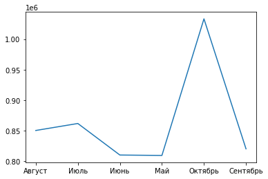

```python
plt.plot(df_2)
```

```
3) Кто из менеджеров привлек для компании больше всего денежных средств в
сентябре 2021?
```

```python
df_3 = df[(df['year']=='2021')&(df['month']=='Сентябрь')].groupby('sale')['sum'].sum()
df_3
```

```
sale
Андреев       133652.50
Васильев       49895.45
Иванов         94770.60
Кузнецова      72228.40
Михайлов        4268.70
Петрова       149344.46
Смирнов       221525.70
Соколов        35183.50
Филимонова     59514.47
Name: sum, dtype: float64
```

```python
df_3.idxmax()
```

```
'Смирнов'
```

#### Ответ: Смирнов

```
4) Какой тип сделок (новая/текущая) был преобладающим в октябре 2021?
```

```python
df_4 = df[(df['year']=='2021')&(df['month']=='Октябрь')]
df_4
```

|  | client_id | sum | status | sale | new/current | document | receiving_date | month | year |
| --- | --- | --- | --- | --- | --- | --- | --- | --- | --- |
| 589 | 15 | 14591.7 | В РАБОТЕ | Иванов | текущая | оригинал | 2021-11-11 00:00:00 | Октябрь | 2021 |
| 590 | 16 | 1291.7 | В РАБОТЕ | Иванов | текущая | оригинал | 2021-11-11 00:00:00 | Октябрь | 2021 |
| 591 | 379 | 6063.7 | В РАБОТЕ | Иванов | новая | оригинал | 2021-11-11 00:00:00 | Октябрь | 2021 |
| 592 | 24 | 18592.7 | ОПЛАЧЕНО | Андреев | текущая | оригинал | 2021-11-12 00:00:00 | Октябрь | 2021 |
| 593 | 24 | 1453.7 | ОПЛАЧЕНО | Андреев | текущая | оригинал | 2021-11-12 00:00:00 | Октябрь | 2021 |
| ... | ... | ... | ... | ... | ... | ... | ... | ... | ... |
| 719 | 285 | 4328.7 | ОПЛАЧЕНО | Васильев | текущая | оригинал | 2021-11-15 00:00:00 | Октябрь | 2021 |
| 720 | 360 | 3096.2 | ОПЛАЧЕНО | Васильев | новая | НЕТ | NaN | Октябрь | 2021 |
| 721 | 360 | 3096.2 | ПРОСРОЧЕНО | Васильев | новая | НЕТ | NaN | Октябрь | 2021 |
| 722 | 373 | 4403.7 | ОПЛАЧЕНО | Михайлов | новая | оригинал | 2021-11-08 00:00:00 | Октябрь | 2021 |
| 723 | 286 | 3978.7 | ОПЛАЧЕНО | Филимонова | текущая | оригинал | 2021-11-15 00:00:00 | Октябрь | 2021 |

135 rows × 9 columns

```python
df_4.groupby('new/current').sum()['sum'].idxmax()
```

```
'текущая'
```

#### Ответ: текущая

```
5) Сколько оригиналов договора по майским сделкам было получено в июне 2021?
```

```python
df_5 = df[(df['year']=='2021')&(df['month']=='Июнь')]
```

```python
df_5.groupby('document')['document'].count()['оригинал']
```

```
126
```

#### Ответ: 126

## Задание:

За каждую заключенную сделку менеджер получает бонус, который рассчитывается следующим образом.

```
1) За новые сделки менеджер получает 7% от суммы, при условии, что статус оплаты «ОПЛАЧЕНО», а также имеется оригинал подписанного договора с клиентом (в рассматриваемом месяце).

2) За текущие сделки менеджер получает 5% от суммы, если она больше 10 тыс., и 3 % от суммы, если меньше. При этом статус оплаты может быть любым, кроме «ПРОСРОЧЕНО», а также необходимо наличие оригинала подписанного договора с клиентом (в рассматриваемом месяце).
```

Бонусы по сделкам, оригиналы для которых приходят позже рассматриваемого месяца, считаются остатком на следующий период, который выплачивается по мере прихода оригиналов. Вычислите остаток каждого из менеджеров на 01.07.2021.

#### Отсеиваем данные по отслеживаемому периоду и наличию оригинала документа

```python
df_task = pd.DataFrame(df[(df['year']=='2021')&((df['month']=='Июнь')|(df['month']=='Май'))&(df['document']=="оригинал")])
```

#### Исправляем тип поля 'receiving_date' на datetime, чтобы было удобнее работать с датой¶

```python
df_task['receiving_date'] = pd.to_datetime(df_task['receiving_date'])
```

#### Определяем проценты для расчёта бонуса

```python
new_deal = 0.07
current_5 = 0.05
current_3 = 0.03
```

#### Инициализируем функцию для рассчёта бонуса за сделку

```python
def calculate_bonus(row):
    if row['status'] == 'ОПЛАЧЕНО' and row['new/current'] == 'новая':
        return row['sum'] * new_deal
    elif row['status'] != 'ПРОСРОЧЕНО':
        if row['sum'] > 10000:
            return row['sum'] * current_5
        else:
            return row['sum'] * current_3
    else:
        return 0
```

#### Применяем ко всем отобранным записям

```python
df_task['bonus'] = df_task.apply(calculate_bonus, axis=1)
```

```python
df_task
```

|  | client_id | sum | status | sale | new/current | document | receiving_date | month | year | bonus |
| --- | --- | --- | --- | --- | --- | --- | --- | --- | --- | --- |
| 1 | 14 | 5452.7 | ОПЛАЧЕНО | Петрова | новая | оригинал | 2021-07-26 | Май | 2021 | 381.689 |
| 2 | 15 | 13991.7 | ОПЛАЧЕНО | Иванов | текущая | оригинал | 2021-06-08 | Май | 2021 | 699.585 |
| 3 | 16 | 719.7 | ОПЛАЧЕНО | Иванов | текущая | оригинал | 2021-06-08 | Май | 2021 | 21.591 |
| 4 | 18 | 4253.7 | ОПЛАЧЕНО | Иванов | текущая | оригинал | 2021-07-07 | Май | 2021 | 127.611 |
| 5 | 20 | 5796.7 | ОПЛАЧЕНО | Кузнецова | текущая | оригинал | 2021-07-15 | Май | 2021 | 173.901 |
| ... | ... | ... | ... | ... | ... | ... | ... | ... | ... | ... |
| 251 | 281 | 5733.7 | ОПЛАЧЕНО | Селиванов | текущая | оригинал | 2021-07-22 | Июнь | 2021 | 172.011 |
| 252 | 282 | 953.7 | ОПЛАЧЕНО | Селиванов | новая | оригинал | 2021-07-16 | Июнь | 2021 | 66.759 |
| 253 | 284 | 8823.7 | ПРОСРОЧЕНО | Филимонова | текущая | оригинал | 2021-09-08 | Июнь | 2021 | 0.000 |
| 254 | 286 | 3453.7 | ОПЛАЧЕНО | Филимонова | текущая | оригинал | 2021-07-22 | Июнь | 2021 | 103.611 |
| 255 | 287 | 6543.7 | ОПЛАЧЕНО | Филимонова | текущая | оригинал | 2021-08-12 | Июнь | 2021 | 196.311 |

249 rows × 10 columns

#### Отсеиваем по заданной дате получения оригиналов 01.07.2021.

```python
from datetime import datetime

datetime_str = '2021-07-01 00:00:00'

datetime_object = datetime.strptime(datetime_str, '%Y-%m-%d %H:%M:%S')

df_task_answer = df_task[df_task['receiving_date'] > datetime_object]
```

#### Вычисляем остаток каждого из менеджеров

```python
df_task_answer.groupby('sale')['bonus'].sum()
```

```
sale
Андреев        3857.4077
Васильев       1037.0490
Иванов         5778.7910
Кузнецова      4496.9501
Петрова       10770.7474
Селиванов      5297.6900
Смирнов        6289.4720
Соколов         269.2110
Филимонова     2317.9579
Name: bonus, dtype: float64
```